# Risk Factor Analysis

## Outcome Variable

**Outcome Variable:** stunted

## Predictor Variables

**Intervention Variable:** fage

**Adjustment Set:**

unadjusted

## Stratifying Variables

The analysis was stratified on these variable(s):

- agecat
- studyid

The following strata were considered:

- agecat: 12 months, studyid: ki0047075b-MAL-ED
- agecat: 12 months, studyid: ki1000304b-SAS-FoodSuppl
- agecat: 12 months, studyid: ki1135781-COHORTS
- agecat: 12 months, studyid: ki1148112-LCNI-5
- agecat: 18 months, studyid: ki0047075b-MAL-ED
- agecat: 18 months, studyid: ki1000304b-SAS-FoodSuppl
- agecat: 18 months, studyid: ki1135781-COHORTS
- agecat: 18 months, studyid: ki1148112-LCNI-5
- agecat: 24 months, studyid: ki0047075b-MAL-ED
- agecat: 24 months, studyid: ki1135781-COHORTS
- agecat: 24 months, studyid: ki1148112-LCNI-5
- agecat: 3 months, studyid: ki0047075b-MAL-ED
- agecat: 3 months, studyid: ki1000304b-SAS-FoodSuppl
- agecat: 3 months, studyid: ki1135781-COHORTS
- agecat: 6 months, studyid: ki0047075b-MAL-ED
- agecat: 6 months, studyid: ki1000304b-SAS-FoodSuppl
- agecat: 6 months, studyid: ki1135781-COHORTS
- agecat: 6 months, studyid: ki1148112-LCNI-5
- agecat: 9 months, studyid: ki0047075b-MAL-ED
- agecat: 9 months, studyid: ki1000304b-SAS-FoodSuppl
- agecat: 9 months, studyid: ki1135781-COHORTS
- agecat: 9 months, studyid: ki1148112-LCNI-5
- agecat: Birth, studyid: ki0047075b-MAL-ED
- agecat: Birth, studyid: ki1135781-COHORTS

### Dropped Strata

Some strata were dropped due to rare outcomes:

- agecat: 12 months, studyid: ki1000304b-SAS-FoodSuppl
- agecat: 12 months, studyid: ki1148112-LCNI-5
- agecat: 18 months, studyid: ki1000304b-SAS-FoodSuppl
- agecat: 18 months, studyid: ki1148112-LCNI-5
- agecat: 24 months, studyid: ki1148112-LCNI-5
- agecat: 3 months, studyid: ki0047075b-MAL-ED
- agecat: 6 months, studyid: ki1148112-LCNI-5
- agecat: 9 months, studyid: ki0047075b-MAL-ED
- agecat: 9 months, studyid: ki1000304b-SAS-FoodSuppl
- agecat: 9 months, studyid: ki1148112-LCNI-5
- agecat: Birth, studyid: ki0047075b-MAL-ED

## Methods Detail

We’re interested in the causal parameters $E[Y_a]$ for all values of $a \in \mathcal{A}$. These parameters represent the mean outcome if, possibly contrary to fact, we intervened to set all units to have $A=a$. Under the randomization and positivity assumptions, these are identified by the statistical parameters $\psi_a=E_W[E_{Y|A,W}(Y|A=a,W)]$. In addition, we’re interested in the mean of $Y$, $E[Y]$ under no intervention (the observed mean). We will estimate these parameters by using SuperLearner to fit the relevant likelihood factors – $E_{Y|A,W}(Y|A=a,W)$ and $p(A=a|W)$, and then updating our likelihood fit using a joint TMLE.

For unadjusted analyses ($W=\{\}$), initial likelihoods were estimated using Lrnr_glm to estimate the simple $E(Y|A)$ and Lrnr_mean to estimate $p(A)$. For adjusted analyses, a small library containing Lrnr_glmnet, Lrnr_xgboost, and Lrnr_mean was used.

Having estimated these parameters, we will then use the delta method to estimate relative risks and attributable risks relative to a prespecified baseline level of $A$.

# Results Detail

## Results Plots

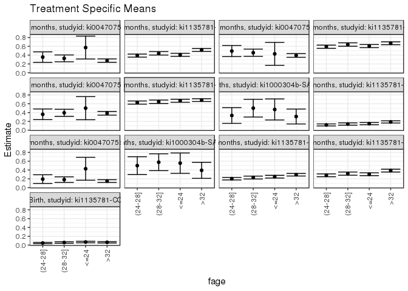

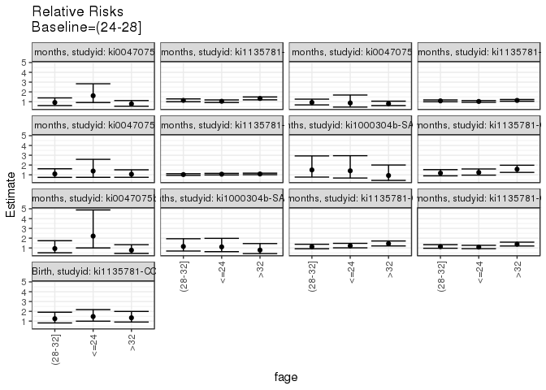

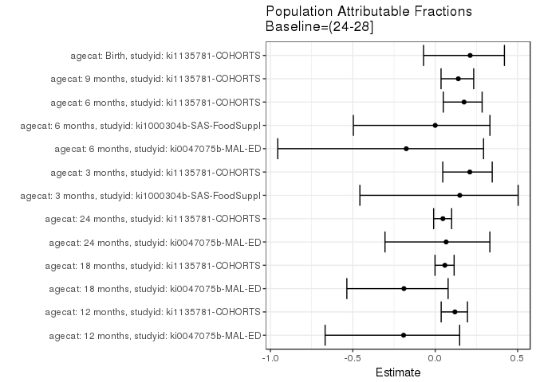

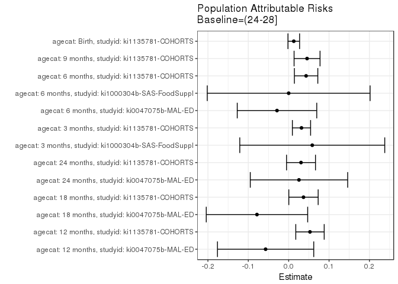

## Data Summary

| agecat | studyid | A | n | nA | nAY0 | nAY1 |
| --- | --- | --- | --- | --- | --- | --- |
| 12 months | ki0047075b-MAL-ED | (24-28] | 739 | 62 | 40 | 22 |
| 12 months | ki0047075b-MAL-ED | (28-32] | 739 | 141 | 95 | 46 |
| 12 months | ki0047075b-MAL-ED | <=24 | 739 | 14 | 6 | 8 |
| 12 months | ki0047075b-MAL-ED | >32 | 739 | 522 | 378 | 144 |
| 12 months | ki1000304b-SAS-FoodSuppl | (24-28] | 92 | 25 | 5 | 20 |
| 12 months | ki1000304b-SAS-FoodSuppl | (28-32] | 92 | 22 | 4 | 18 |
| 12 months | ki1000304b-SAS-FoodSuppl | <=24 | 92 | 17 | 4 | 13 |
| 12 months | ki1000304b-SAS-FoodSuppl | >32 | 92 | 28 | 6 | 22 |
| 12 months | ki1135781-COHORTS | (24-28] | 3016 | 740 | 452 | 288 |
| 12 months | ki1135781-COHORTS | (28-32] | 3016 | 626 | 350 | 276 |
| 12 months | ki1135781-COHORTS | <=24 | 3016 | 757 | 450 | 307 |
| 12 months | ki1135781-COHORTS | >32 | 3016 | 893 | 431 | 462 |
| 12 months | ki1148112-LCNI-5 | (24-28] | 38 | 9 | 5 | 4 |
| 12 months | ki1148112-LCNI-5 | (28-32] | 38 | 8 | 6 | 2 |
| 12 months | ki1148112-LCNI-5 | <=24 | 38 | 6 | 4 | 2 |
| 12 months | ki1148112-LCNI-5 | >32 | 38 | 15 | 10 | 5 |
| 18 months | ki0047075b-MAL-ED | (24-28] | 738 | 61 | 31 | 30 |
| 18 months | ki0047075b-MAL-ED | (28-32] | 738 | 141 | 77 | 64 |
| 18 months | ki0047075b-MAL-ED | <=24 | 738 | 14 | 8 | 6 |
| 18 months | ki0047075b-MAL-ED | >32 | 738 | 522 | 317 | 205 |
| 18 months | ki1000304b-SAS-FoodSuppl | (24-28] | 84 | 24 | 2 | 22 |
| 18 months | ki1000304b-SAS-FoodSuppl | (28-32] | 84 | 22 | 3 | 19 |
| 18 months | ki1000304b-SAS-FoodSuppl | <=24 | 84 | 16 | 2 | 14 |
| 18 months | ki1000304b-SAS-FoodSuppl | >32 | 84 | 22 | 3 | 19 |
| 18 months | ki1135781-COHORTS | (24-28] | 2833 | 704 | 288 | 416 |
| 18 months | ki1135781-COHORTS | (28-32] | 2833 | 592 | 213 | 379 |
| 18 months | ki1135781-COHORTS | <=24 | 2833 | 718 | 283 | 435 |
| 18 months | ki1135781-COHORTS | >32 | 2833 | 819 | 271 | 548 |
| 18 months | ki1148112-LCNI-5 | (24-28] | 43 | 10 | 7 | 3 |
| 18 months | ki1148112-LCNI-5 | (28-32] | 43 | 10 | 6 | 4 |

[output cut: 82 more lines]

## Results Table

### Parameter: TSM

| agecat | studyid | intervention_level | baseline_level | estimate | ci_lower | ci_upper |
| --- | --- | --- | --- | --- | --- | --- |
| 12 months | ki0047075b-MAL-ED | (24-28] | NA | 0.3548387 | 0.2356608 | 0.4740167 |
| 12 months | ki0047075b-MAL-ED | (28-32] | NA | 0.3262411 | 0.2488031 | 0.4036791 |
| 12 months | ki0047075b-MAL-ED | <=24 | NA | 0.5714286 | 0.3120281 | 0.8308290 |
| 12 months | ki0047075b-MAL-ED | >32 | NA | 0.2758621 | 0.2374946 | 0.3142296 |
| 12 months | ki1135781-COHORTS | (24-28] | NA | 0.3891892 | 0.3540543 | 0.4243240 |
| 12 months | ki1135781-COHORTS | (28-32] | NA | 0.4408946 | 0.4019948 | 0.4797944 |
| 12 months | ki1135781-COHORTS | <=24 | NA | 0.4055482 | 0.3705656 | 0.4405308 |
| 12 months | ki1135781-COHORTS | >32 | NA | 0.5173572 | 0.4845777 | 0.5501367 |
| 18 months | ki0047075b-MAL-ED | (24-28] | NA | 0.4918033 | 0.3662612 | 0.6173453 |
| 18 months | ki0047075b-MAL-ED | (28-32] | NA | 0.4539007 | 0.3716671 | 0.5361343 |
| 18 months | ki0047075b-MAL-ED | <=24 | NA | 0.4285714 | 0.1691708 | 0.6879721 |
| 18 months | ki0047075b-MAL-ED | >32 | NA | 0.3927203 | 0.3507982 | 0.4346424 |
| 18 months | ki1135781-COHORTS | (24-28] | NA | 0.5909091 | 0.5545838 | 0.6272343 |
| 18 months | ki1135781-COHORTS | (28-32] | NA | 0.6402027 | 0.6015347 | 0.6788707 |
| 18 months | ki1135781-COHORTS | <=24 | NA | 0.6058496 | 0.5700996 | 0.6415996 |
| 18 months | ki1135781-COHORTS | >32 | NA | 0.6691087 | 0.6368777 | 0.7013397 |
| 24 months | ki0047075b-MAL-ED | (24-28] | NA | 0.3606557 | 0.2400713 | 0.4812402 |
| 24 months | ki0047075b-MAL-ED | (28-32] | NA | 0.3943662 | 0.3139297 | 0.4748027 |
| 24 months | ki0047075b-MAL-ED | <=24 | NA | 0.5000000 | 0.2379112 | 0.7620888 |
| 24 months | ki0047075b-MAL-ED | >32 | NA | 0.3838772 | 0.3420890 | 0.4256653 |
| 24 months | ki1135781-COHORTS | (24-28] | NA | 0.6271429 | 0.5913143 | 0.6629714 |
| 24 months | ki1135781-COHORTS | (28-32] | NA | 0.6450512 | 0.6063027 | 0.6837997 |
| 24 months | ki1135781-COHORTS | <=24 | NA | 0.6684932 | 0.6343379 | 0.7026484 |
| 24 months | ki1135781-COHORTS | >32 | NA | 0.6823529 | 0.6510496 | 0.7136563 |
| 3 months | ki1000304b-SAS-FoodSuppl | (24-28] | NA | 0.3333333 | 0.1545981 | 0.5120686 |
| 3 months | ki1000304b-SAS-FoodSuppl | (28-32] | NA | 0.5000000 | 0.2989228 | 0.7010772 |
| 3 months | ki1000304b-SAS-FoodSuppl | <=24 | NA | 0.4705882 | 0.2320867 | 0.7090898 |
| 3 months | ki1000304b-SAS-FoodSuppl | >32 | NA | 0.3103448 | 0.1410914 | 0.4795983 |
| 3 months | ki1135781-COHORTS | (24-28] | NA | 0.1194969 | 0.0969454 | 0.1420483 |
| 3 months | ki1135781-COHORTS | (28-32] | NA | 0.1401180 | 0.1139864 | 0.1662496 |
| 3 months | ki1135781-COHORTS | <=24 | NA | 0.1487805 | 0.1244191 | 0.1731419 |
| 3 months | ki1135781-COHORTS | >32 | NA | 0.1879620 | 0.1630755 | 0.2128485 |
| 6 months | ki0047075b-MAL-ED | (24-28] | NA | 0.1935484 | 0.0951406 | 0.2919562 |
| 6 months | ki0047075b-MAL-ED | (28-32] | NA | 0.1818182 | 0.1185600 | 0.2450764 |
| 6 months | ki0047075b-MAL-ED | <=24 | NA | 0.4285714 | 0.1691715 | 0.6879714 |
| 6 months | ki0047075b-MAL-ED | >32 | NA | 0.1494253 | 0.1188216 | 0.1800290 |
| 6 months | ki1000304b-SAS-FoodSuppl | (24-28] | NA | 0.5000000 | 0.2989119 | 0.7010881 |
| 6 months | ki1000304b-SAS-FoodSuppl | (28-32] | NA | 0.5769231 | 0.3860240 | 0.7678222 |
| 6 months | ki1000304b-SAS-FoodSuppl | <=24 | NA | 0.5555556 | 0.3247968 | 0.7863143 |
| 6 months | ki1000304b-SAS-FoodSuppl | >32 | NA | 0.3928571 | 0.2110103 | 0.5747039 |
| 6 months | ki1135781-COHORTS | (24-28] | NA | 0.2035040 | 0.1745309 | 0.2324772 |
| 6 months | ki1135781-COHORTS | (28-32] | NA | 0.2293292 | 0.1967790 | 0.2618794 |
| 6 months | ki1135781-COHORTS | <=24 | NA | 0.2483995 | 0.2180911 | 0.2787078 |
| 6 months | ki1135781-COHORTS | >32 | NA | 0.2928177 | 0.2631653 | 0.3224700 |
| 9 months | ki1135781-COHORTS | (24-28] | NA | 0.2796272 | 0.2475226 | 0.3117318 |
| 9 months | ki1135781-COHORTS | (28-32] | NA | 0.3181818 | 0.2820341 | 0.3543295 |
| 9 months | ki1135781-COHORTS | <=24 | NA | 0.3043478 | 0.2720928 | 0.3366028 |
| 9 months | ki1135781-COHORTS | >32 | NA | 0.3867713 | 0.3548063 | 0.4187363 |
| Birth | ki1135781-COHORTS | (24-28] | NA | 0.0470446 | 0.0326292 | 0.0614601 |
| Birth | ki1135781-COHORTS | (28-32] | NA | 0.0585714 | 0.0411734 | 0.0759695 |
| Birth | ki1135781-COHORTS | <=24 | NA | 0.0690449 | 0.0521858 | 0.0859039 |
| Birth | ki1135781-COHORTS | >32 | NA | 0.0630342 | 0.0474629 | 0.0786055 |

### Parameter: E(Y)

| agecat | studyid | intervention_level | baseline_level | estimate | ci_lower | ci_upper |
| --- | --- | --- | --- | --- | --- | --- |
| 12 months | ki0047075b-MAL-ED | NA | NA | 0.2976996 | 0.2943266 | 0.3010726 |
| 12 months | ki1135781-COHORTS | NA | NA | 0.4419761 | 0.4401216 | 0.4438307 |
| 18 months | ki0047075b-MAL-ED | NA | NA | 0.4132791 | 0.4108540 | 0.4157042 |
| 18 months | ki1135781-COHORTS | NA | NA | 0.6276032 | 0.6264469 | 0.6287596 |
| 24 months | ki0047075b-MAL-ED | NA | NA | 0.3861789 | 0.3848950 | 0.3874627 |
| 24 months | ki1135781-COHORTS | NA | NA | 0.6577111 | 0.6569167 | 0.6585055 |
| 3 months | ki1000304b-SAS-FoodSuppl | NA | NA | 0.3917526 | 0.3751125 | 0.4083927 |
| 3 months | ki1135781-COHORTS | NA | NA | 0.1512346 | 0.1503439 | 0.1521252 |
| 6 months | ki0047075b-MAL-ED | NA | NA | 0.1646424 | 0.1617549 | 0.1675298 |
| 6 months | ki1000304b-SAS-FoodSuppl | NA | NA | 0.5000000 | 0.4850470 | 0.5149530 |
| 6 months | ki1135781-COHORTS | NA | NA | 0.2466601 | 0.2454643 | 0.2478560 |
| 9 months | ki1135781-COHORTS | NA | NA | 0.3251714 | 0.3236963 | 0.3266465 |
| Birth | ki1135781-COHORTS | NA | NA | 0.0596881 | 0.0594123 | 0.0599638 |

### Parameter: RR

| agecat | studyid | intervention_level | baseline_level | estimate | ci_lower | ci_upper |
| --- | --- | --- | --- | --- | --- | --- |
| 12 months | ki0047075b-MAL-ED | (28-32] | (24-28] | 0.9194068 | 0.6093870 | 1.387146 |
| 12 months | ki0047075b-MAL-ED | <=24 | (24-28] | 1.6103896 | 0.9155635 | 2.832523 |
| 12 months | ki0047075b-MAL-ED | >32 | (24-28] | 0.7774295 | 0.5404864 | 1.118246 |
| 12 months | ki1135781-COHORTS | (28-32] | (24-28] | 1.1328541 | 0.9985100 | 1.285273 |
| 12 months | ki1135781-COHORTS | <=24 | (24-28] | 1.0420336 | 0.9197176 | 1.180617 |
| 12 months | ki1135781-COHORTS | >32 | (24-28] | 1.3293206 | 1.1905029 | 1.484325 |
| 18 months | ki0047075b-MAL-ED | (28-32] | (24-28] | 0.9229314 | 0.6748762 | 1.262161 |
| 18 months | ki0047075b-MAL-ED | <=24 | (24-28] | 0.8714286 | 0.4517994 | 1.680807 |
| 18 months | ki0047075b-MAL-ED | >32 | (24-28] | 0.7985313 | 0.6055179 | 1.053069 |
| 18 months | ki1135781-COHORTS | (28-32] | (24-28] | 1.0834200 | 0.9939603 | 1.180931 |
| 18 months | ki1135781-COHORTS | <=24 | (24-28] | 1.0252839 | 0.9415370 | 1.116480 |
| 18 months | ki1135781-COHORTS | >32 | (24-28] | 1.1323377 | 1.0472692 | 1.224316 |
| 24 months | ki0047075b-MAL-ED | (28-32] | (24-28] | 1.0934699 | 0.7391207 | 1.617701 |
| 24 months | ki0047075b-MAL-ED | <=24 | (24-28] | 1.3863636 | 0.7444960 | 2.581618 |
| 24 months | ki0047075b-MAL-ED | >32 | (24-28] | 1.0643867 | 0.7488444 | 1.512890 |
| 24 months | ki1135781-COHORTS | (28-32] | (24-28] | 1.0285554 | 0.9467276 | 1.117456 |
| 24 months | ki1135781-COHORTS | <=24 | (24-28] | 1.0659344 | 0.9872893 | 1.150844 |
| 24 months | ki1135781-COHORTS | >32 | (24-28] | 1.0880343 | 1.0111652 | 1.170747 |
| 3 months | ki1000304b-SAS-FoodSuppl | (28-32] | (24-28] | 1.5000000 | 0.7673655 | 2.932110 |
| 3 months | ki1000304b-SAS-FoodSuppl | <=24 | (24-28] | 1.4117647 | 0.6750424 | 2.952525 |
| 3 months | ki1000304b-SAS-FoodSuppl | >32 | (24-28] | 0.9310345 | 0.4333205 | 2.000425 |
| 3 months | ki1135781-COHORTS | (28-32] | (24-28] | 1.1725664 | 0.8993088 | 1.528854 |
| 3 months | ki1135781-COHORTS | <=24 | (24-28] | 1.2450578 | 0.9697949 | 1.598450 |
| 3 months | ki1135781-COHORTS | >32 | (24-28] | 1.5729450 | 1.2490915 | 1.980765 |
| 6 months | ki0047075b-MAL-ED | (28-32] | (24-28] | 0.9393939 | 0.5073244 | 1.739441 |
| 6 months | ki0047075b-MAL-ED | <=24 | (24-28] | 2.2142857 | 1.0044595 | 4.881293 |
| 6 months | ki0047075b-MAL-ED | >32 | (24-28] | 0.7720307 | 0.4462518 | 1.335639 |
| 6 months | ki1000304b-SAS-FoodSuppl | (28-32] | (24-28] | 1.1538462 | 0.6854351 | 1.942359 |
| 6 months | ki1000304b-SAS-FoodSuppl | <=24 | (24-28] | 1.1111111 | 0.6232522 | 1.980848 |
| 6 months | ki1000304b-SAS-FoodSuppl | >32 | (24-28] | 0.7857143 | 0.4255574 | 1.450678 |
| 6 months | ki1135781-COHORTS | (28-32] | (24-28] | 1.1269023 | 0.9216740 | 1.377829 |
| 6 months | ki1135781-COHORTS | <=24 | (24-28] | 1.2206121 | 1.0119206 | 1.472343 |
| 6 months | ki1135781-COHORTS | >32 | (24-28] | 1.4388789 | 1.2082250 | 1.713565 |
| 9 months | ki1135781-COHORTS | (28-32] | (24-28] | 1.1378788 | 0.9681645 | 1.337343 |
| 9 months | ki1135781-COHORTS | <=24 | (24-28] | 1.0884058 | 0.9309638 | 1.272474 |
| 9 months | ki1135781-COHORTS | >32 | (24-28] | 1.3831678 | 1.2007088 | 1.593353 |
| Birth | ki1135781-COHORTS | (28-32] | (24-28] | 1.2450183 | 0.8125222 | 1.907727 |
| Birth | ki1135781-COHORTS | <=24 | (24-28] | 1.4676463 | 0.9918833 | 2.171612 |
| Birth | ki1135781-COHORTS | >32 | (24-28] | 1.3398805 | 0.9039200 | 1.986105 |

### Parameter: PAR

| agecat | studyid | intervention_level | baseline_level | estimate | ci_lower | ci_upper |
| --- | --- | --- | --- | --- | --- | --- |
| 12 months | ki0047075b-MAL-ED | (24-28] | NA | -0.0571391 | -0.1763648 | 0.0620866 |
| 12 months | ki1135781-COHORTS | (24-28] | NA | 0.0527869 | 0.0176032 | 0.0879707 |
| 18 months | ki0047075b-MAL-ED | (24-28] | NA | -0.0785241 | -0.2040896 | 0.0470413 |
| 18 months | ki1135781-COHORTS | (24-28] | NA | 0.0366942 | 0.0003505 | 0.0730378 |
| 24 months | ki0047075b-MAL-ED | (24-28] | NA | 0.0255231 | -0.0950682 | 0.1461144 |
| 24 months | ki1135781-COHORTS | (24-28] | NA | 0.0305682 | -0.0052691 | 0.0664056 |
| 3 months | ki1000304b-SAS-FoodSuppl | (24-28] | NA | 0.0584192 | -0.1210889 | 0.2379274 |
| 3 months | ki1135781-COHORTS | (24-28] | NA | 0.0317377 | 0.0091686 | 0.0543068 |
| 6 months | ki0047075b-MAL-ED | (24-28] | NA | -0.0289060 | -0.1273561 | 0.0695441 |
| 6 months | ki1000304b-SAS-FoodSuppl | (24-28] | NA | 0.0000000 | -0.2016433 | 0.2016433 |
| 6 months | ki1135781-COHORTS | (24-28] | NA | 0.0431561 | 0.0141583 | 0.0721539 |
| 9 months | ki1135781-COHORTS | (24-28] | NA | 0.0455442 | 0.0134058 | 0.0776827 |
| Birth | ki1135781-COHORTS | (24-28] | NA | 0.0126434 | -0.0017746 | 0.0270615 |

### Parameter: PAF

| agecat | studyid | intervention_level | baseline_level | estimate | ci_lower | ci_upper |
| --- | --- | --- | --- | --- | --- | --- |
| 12 months | ki0047075b-MAL-ED | (24-28] | NA | -0.1919355 | -0.6680156 | 0.1482632 |
| 12 months | ki1135781-COHORTS | (24-28] | NA | 0.1194339 | 0.0361464 | 0.1955245 |
| 18 months | ki0047075b-MAL-ED | (24-28] | NA | -0.1900027 | -0.5361693 | 0.0781573 |
| 18 months | ki1135781-COHORTS | (24-28] | NA | 0.0584671 | -0.0012559 | 0.1146278 |
| 24 months | ki0047075b-MAL-ED | (24-28] | NA | 0.0660915 | -0.3047189 | 0.3315149 |
| 24 months | ki1135781-COHORTS | (24-28] | NA | 0.0464767 | -0.0095969 | 0.0994360 |
| 3 months | ki1000304b-SAS-FoodSuppl | (24-28] | NA | 0.1491228 | -0.4570270 | 0.5031032 |
| 3 months | ki1135781-COHORTS | (24-28] | NA | 0.2098575 | 0.0456548 | 0.3458079 |
| 6 months | ki0047075b-MAL-ED | (24-28] | NA | -0.1755685 | -0.9552037 | 0.2931881 |
| 6 months | ki1000304b-SAS-FoodSuppl | (24-28] | NA | 0.0000000 | -0.4967357 | 0.3318793 |
| 6 months | ki1135781-COHORTS | (24-28] | NA | 0.1749618 | 0.0486487 | 0.2845040 |
| 9 months | ki1135781-COHORTS | (24-28] | NA | 0.1400622 | 0.0353534 | 0.2334053 |
| Birth | ki1135781-COHORTS | (24-28] | NA | 0.2118251 | -0.0708146 | 0.4198625 |